# Histograms from Data

Nikolai Lipscomb

January 14, 2020

We will import a dataset regarding patient unpunctuality at various UNC clinics. The first variable (column) gives the standard form time for appointment time. We will focus on variables 2-3 corresponding to columns 2-3. The second column corresponds to unpunctuality in minutes (negative if early, positive if late) relative to the appointment time states in simple numerical hourly form as the third variable. Note that a simple time of 21.5 corresponds to 9:30pm.

```r
library("readxl")
library("mixtools")
fulldata <- read_excel("simple_unpunct_data.xlsx")
N = dim(fulldata)[1]
N
```

```
## [1] 310273
```

Note that there are 310,273 observations (rows) in this dataset. We will create a new dataset ‘Unpunctual11’ that will give us all values of the variable ‘unpunctuality’ for appointments set at 11am. We will examine summary statistics of this univariate dataset. Note now that there are 16,553 observations in this set.

```r
Unpunctual11 = fulldata[fulldata$Simple_time == 11, 2]
N11 = dim(Unpunctual11)[1]
N11
```

```
## [1] 16553
```

```r
summary(Unpunctual11)
```

```
##  unpunctuality
##  Min.   :-660.00
##  1st Qu.: -84.00
##  Median : -31.00
##  Mean   : -45.62
##  3rd Qu.:  -5.00
##  Max.   : 575.00
```

Above we see the five number summary plus the mean for unpunctuality. So we know, on average, patients within the dataset scheduled for 11am appointments arrived 45.62 minutes early.

We will treat unpunctuality as a continuous random variable for the purpose of this analysis.

The main goal of this report is to demonstrate how we go from histograms to densities for continuous random variables. Remember, relative frequency histograms capture an area equal to 1, corresponding to 100%.

We know that our set of 16,553 observations can be seen as a decently large sample representing a population: we might try to generalize this to all patients that make appointments at 11am at UNC clinics over the period the data was collected (assuming patients were selected via a valid sampling process). Instead, we will treat the 16,553 observations as our population and sample from this set with various size samples and examine the associated histograms.

So, from now on, define the set of 16,553 observations as our population.

Below we will generate the histogram of the unpunctuality variable for a simple random sample (SRS) of $n=25$. When we create a histogram, we can choose the number of classes. As we will see, we can’t have too many classes when we only have 25 datapoints.

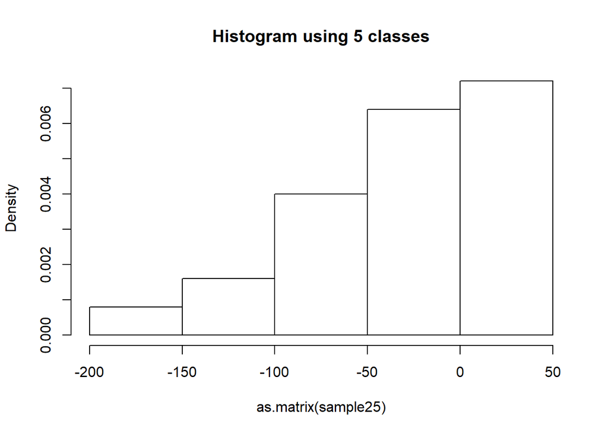

```r
set.seed(1137)
sample25 = Unpunctual11[sample(1:N11, 25, replace=FALSE),1]
hist(as.matrix(sample25), prob=T, breaks=4, main="Histogram using 5 classes")
```

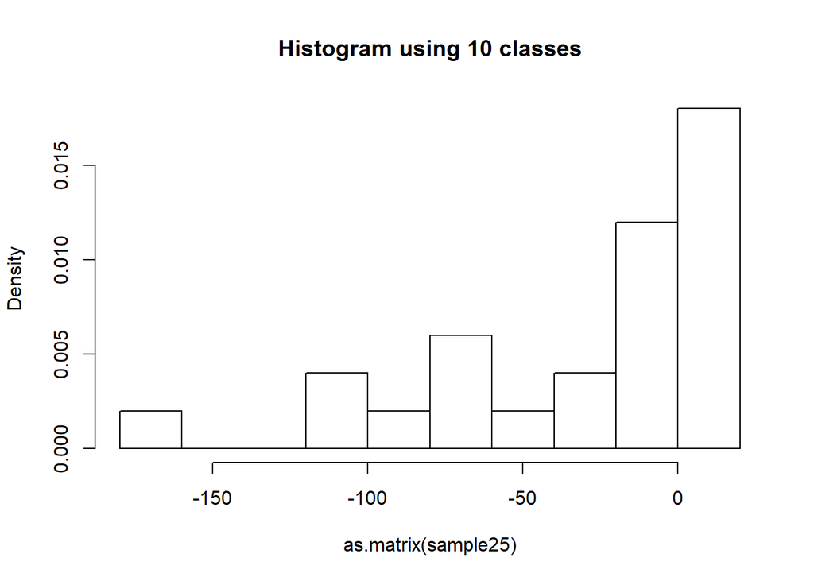

```r
hist(as.matrix(sample25), prob=T, breaks=9, main="Histogram using 10 classes")
```

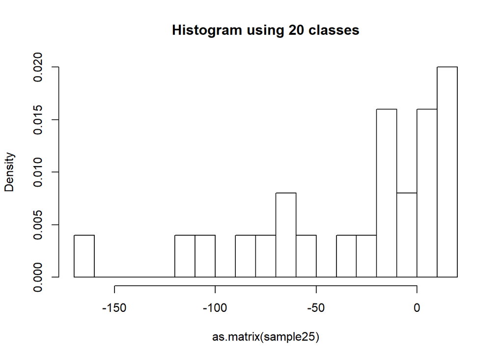

```r
hist(as.matrix(sample25), prob=T, breaks=19, main="Histogram using 20 classes")
```

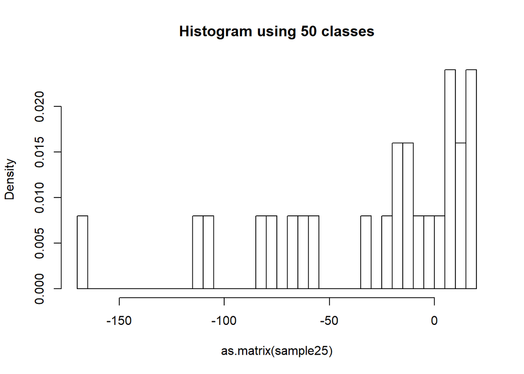

```r
hist(as.matrix(sample25), prob=T, breaks=49, main="Histogram using 50 classes")
```

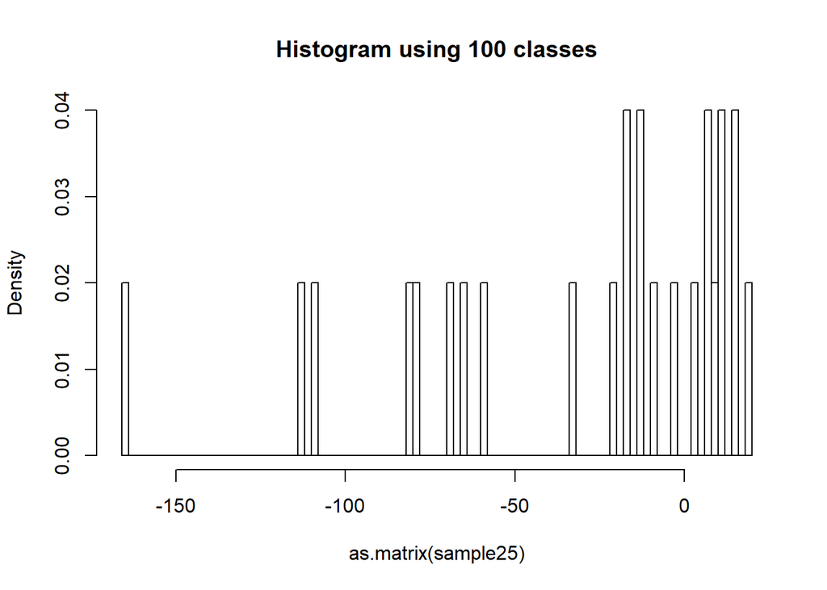

```r
hist(as.matrix(sample25), prob=T, breaks=99, main="Histogram using 100 classes")
```

As we can see, with only 25 data points, we can have at most 25 classes with nonzero bar heights, so it doesn’t make sense to have too many classes.

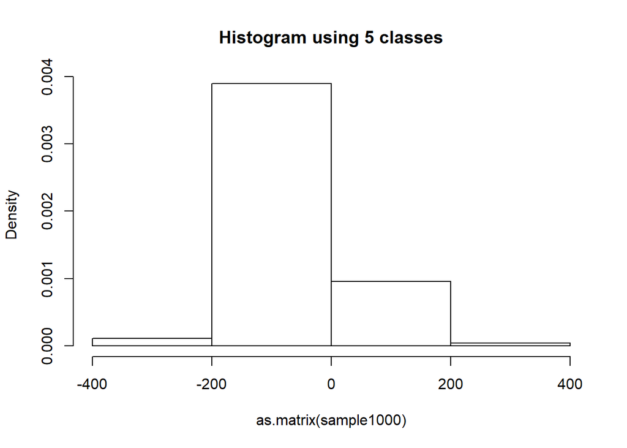

```r
set.seed(237)
sample1000 = Unpunctual11[sample(1:N11, 1000, replace=FALSE),1]
hist(as.matrix(sample1000), prob=T, breaks=4, main="Histogram using 5 classes")
```

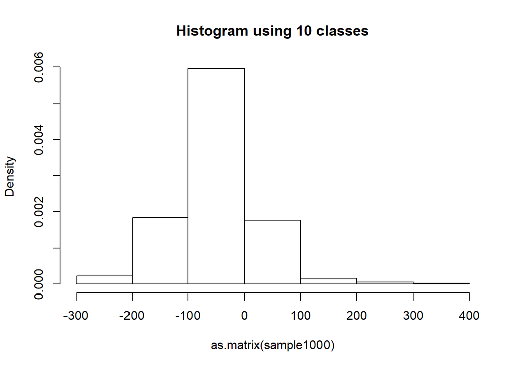

```r
hist(as.matrix(sample1000), prob=T, breaks=9, main="Histogram using 10 classes")
```

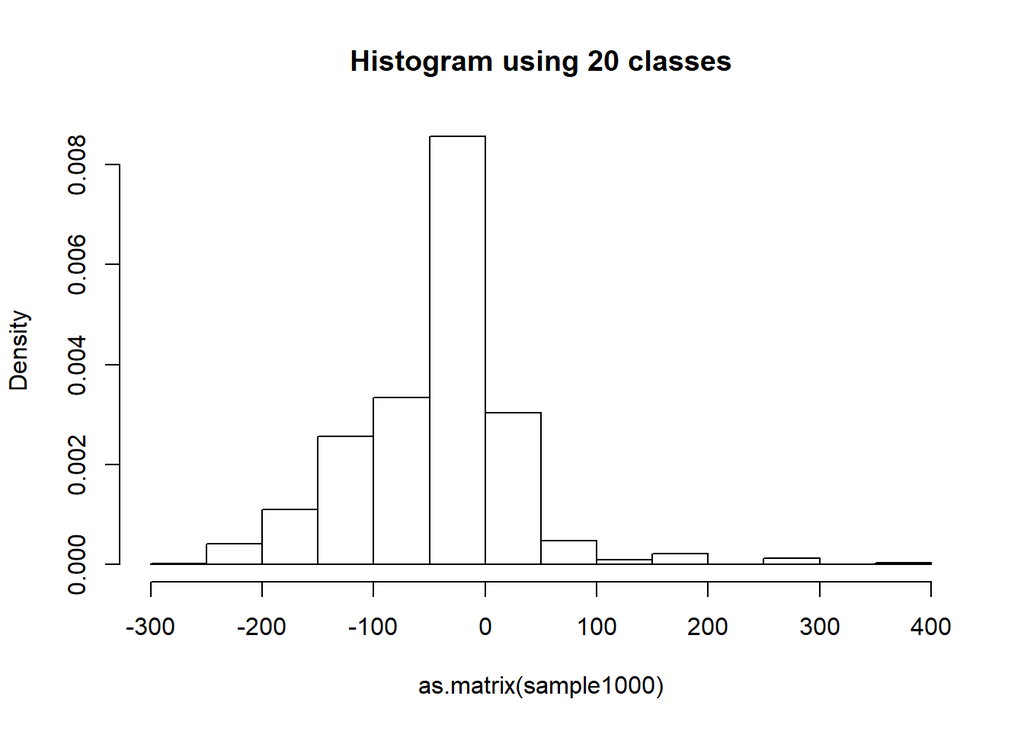

```r
hist(as.matrix(sample1000), prob=T, breaks=19, main="Histogram using 20 classes")
```

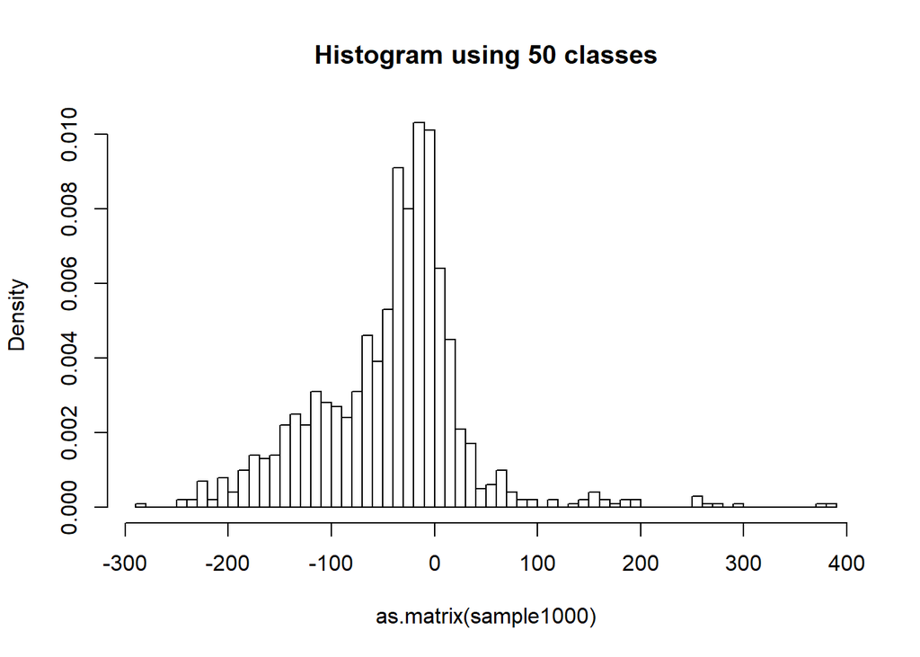

```r
hist(as.matrix(sample1000), prob=T, breaks=49, main="Histogram using 50 classes")
```

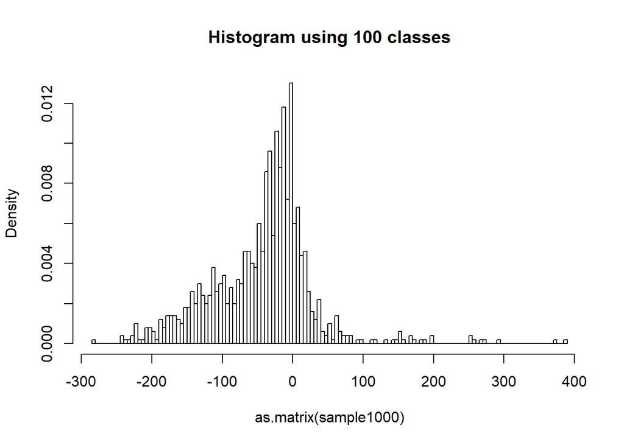

```r
hist(as.matrix(sample1000), prob=T, breaks=99, main="Histogram using 100 classes")
```

As we can see, since the sample size is sufficiently large, it is more useful to see more classes in the histogram. For example, $(-200, 0)$ is a single class in the first histogram, but in the last histogram we see that values close to $-200$ are quite sparse where the majority in that interval are in fact clustered in the upper half of that interval which we can see in the last histogram.

Now we will examine the histogram of our population (consisting of every row of Unpunctual11).

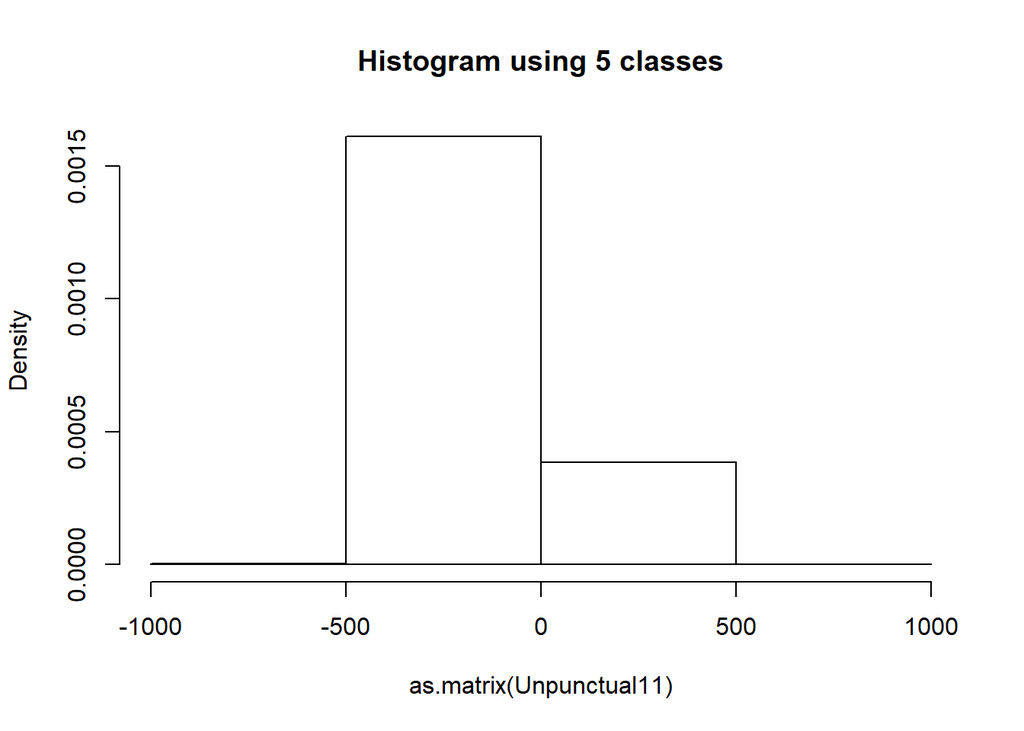

```r
set.seed(1137)
hist(as.matrix(Unpunctual11), prob=T, breaks=4, main="Histogram using 5 classes")
```

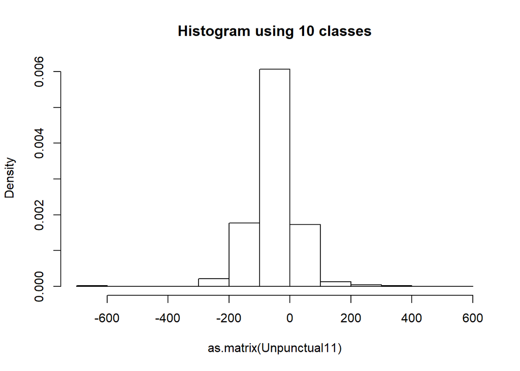

```r
hist(as.matrix(Unpunctual11), prob=T, breaks=9, main="Histogram using 10 classes")
```

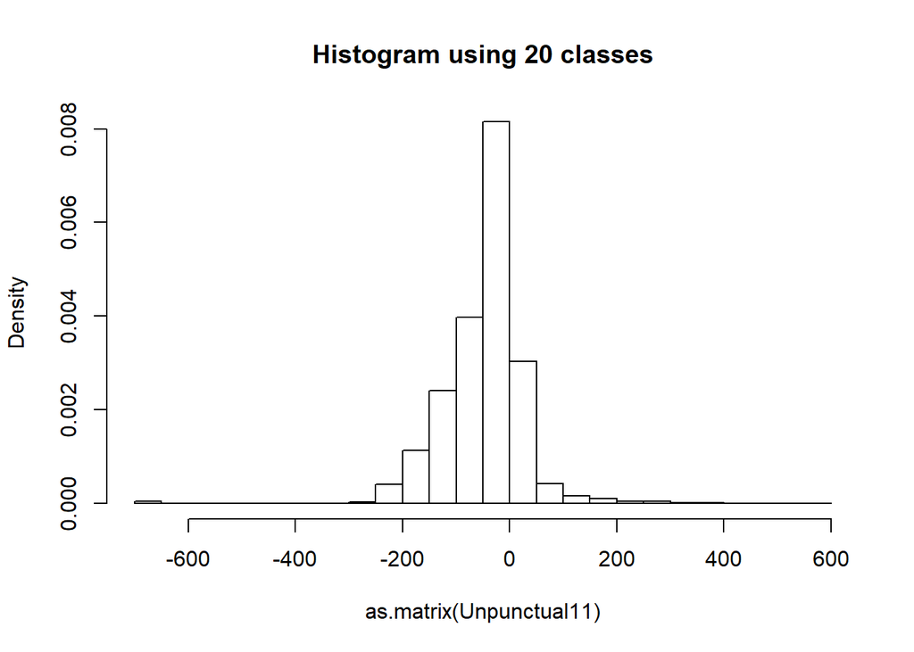

```r
hist(as.matrix(Unpunctual11), prob=T, breaks=19, main="Histogram using 20 classes")
```

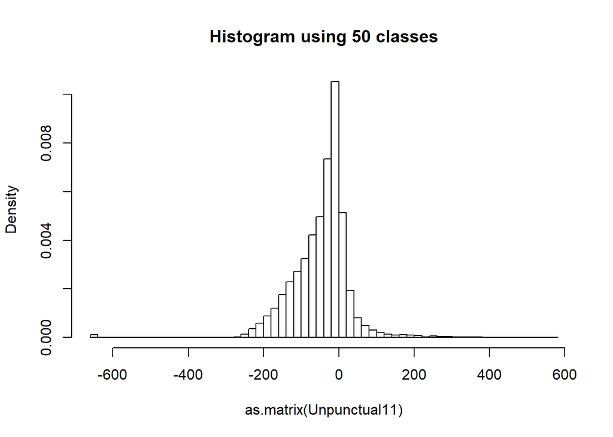

```r
hist(as.matrix(Unpunctual11), prob=T, breaks=49, main="Histogram using 50 classes")
```

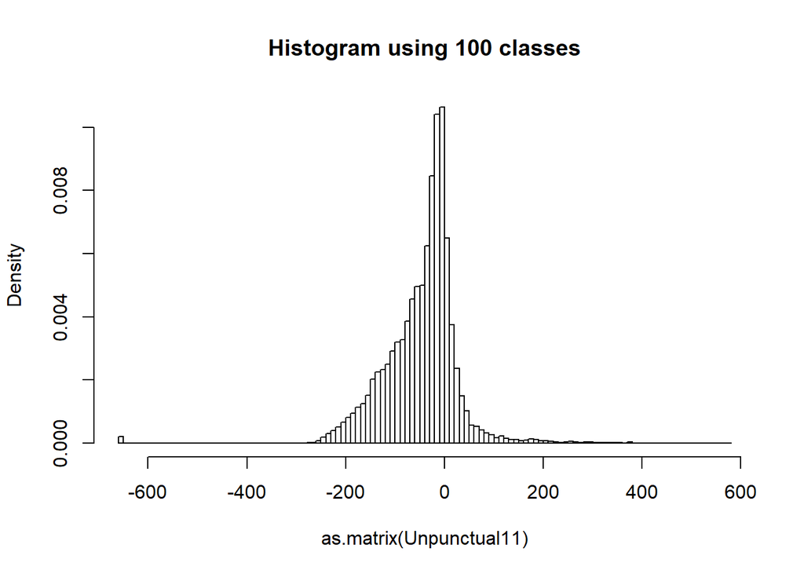

```r
hist(as.matrix(Unpunctual11), prob=T, breaks=99, main="Histogram using 100 classes")
```

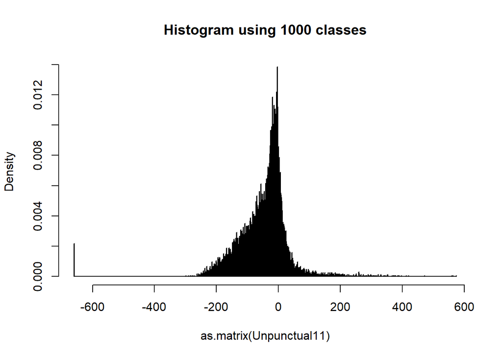

```r
hist(as.matrix(Unpunctual11), prob=T, breaks=999, main="Histogram using 1000 classes")
```

If we look at the very last histogram, which uses 1000 classes, we get an idea of the true distribution. Looking at this leads to the idea of a density. Is there a function that could approximate the mountainous curve formed by the last histogram? Such a nice function would represent what we call a parametric distribution (distribution described by parametres).

Using some domain knowledge regarding patient unpunctuality, one might argue that a Generalised Laplace Distribution can reasonably approximate the shape formed by the last histogram. We will determine the parametres of this distribution below.

```r
Early11 = -Unpunctual11[Unpunctual11$unpunctuality <= 0, 1]
Late11 = Unpunctual11[Unpunctual11$unpunctuality > 0, 1]
N.early = dim(Early11)[1]
N.late = dim(Late11)[1]
Prob.early = N.early/N11
Prob.late = N.late/N11
set.seed(117)
Early.EM <- expRMM_EM(as.matrix(Early11), d=NULL, lambda=NULL, rate=NULL, k=1)
```

```
## number of iterations = 3
```

```r
rate.early = Early.EM$rate
Late.EM <- expRMM_EM(as.matrix(Late11), d=NULL, lambda=NULL, rate=NULL, k=1)
```

```
## number of iterations = 3
```

```r
rate.late = Late.EM$rate
f = function(x)
{
    if (x>0){
        Prob.late*rate.late*exp(-rate.late*x)
    }
  else{
        Prob.early*rate.early*exp(rate.early*x)
    }
}
Xs = seq(-600, 600, 0.01)
Ys = rep(0, length(Xs))
for (i in 1:length(Xs)){
  Ys[i] = f(Xs[i])
}
Prob.early
```

```
## [1] 0.8072857
```

```r
rate.early
```

```
## [1] 0.01508743
```

```r
Prob.late
```

```
## [1] 0.1927143
```

```r
rate.late
```

```
## [1] 0.02443976
```

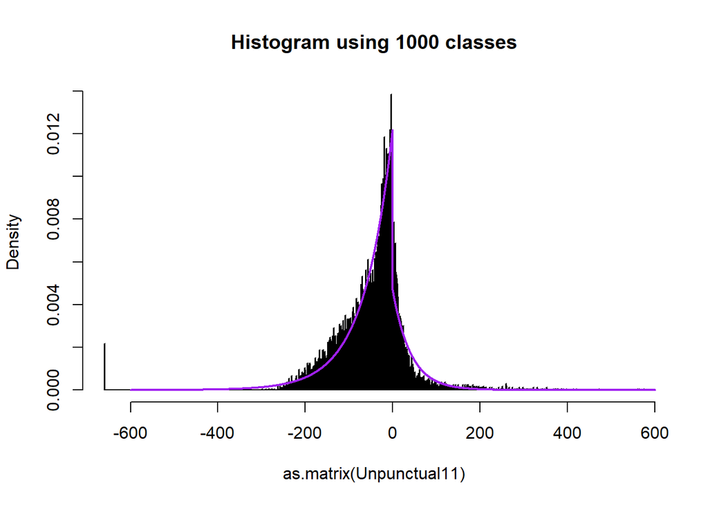

```r
hist(as.matrix(Unpunctual11), prob=T, breaks=999, main="Histogram using 1000 classes")
lines(Xs, Ys, col="purple", lwd=2)
```

While quite a good fit from inspection, one may be able to find a different parametric distribution that even better fits the data. Regardless, our main take-away is that we often represent population distributions with functions that can be described mathematically like we did for $f(x)$.